# R Notebook

We’ve measured BMI as an outcome. But there are plenty of other outcome measure we could use to measure health and they have less problematic health stigma relationships. What can we identify? Janet Tomiyama suggests:

> They have the global self-rated health, but they also have the Has a doctor ever told you…about some cardiovascular disease items, and a lot on cancer (why?? Oh bc it’s an NCI study).

> I think your best bet would be these non-cancer items:

The following are in all relevant cycles which is good:

> In general, would you say your health is…

> Has a doctor or other health professional ever told you that you had any of the following medical conditions: Diabetes or high blood sugar? Has a doctor or other health professional ever told you that you had any of the following medical conditions: High blood pressure or hypertension? Has a doctor or other health professional ever told you that you had any of the following medical conditions: A heart condition such as heart attack, angina or congestive heart failure?

Is there a reason we wouldn’t go beyond HINTS 5? We want to know about healthy eating behavior.

Oh… rurality. Only one HINTS study includes rurality; that’s HINTS5, Cycle 1 to 4. That’s what I use for the data here.

I’ll also add:

> Have you ever been diagnosed as having cancer?

Pre-registration: https://osf.io/h98wp

So these items are:

- `GeneralHealth`
- `MedConditions_Diabetes`
- `MedConditions_HighBP`
- `MedConditions_HeartCondition`
- `EverHadCancer`

```r
library(dplyr)
source("HINTS_preprocessing.R")
hints5 <-get_hints5()
```

```
[1] "hints5_cycle2_public.sav"
[1] TRUE
[1] "PR_RUCA_2010TRUE"
[1] "RUC2013TRUE"
[1] TRUE
[1] TRUE
[1] "hints5_cycle1_public.sav"
[1] TRUE
[1] "PR_RUCA_2010TRUE"
[1] "RUC2013TRUE"
[1] TRUE
[1] TRUE
[1] "hints5_cycle3_public.sav"
[1] TRUE
[1] "PR_RUCA_2010TRUE"
[1] "RUC2013TRUE"
[1] TRUE
[1] TRUE
[1] "hints5_cycle4_public.sav"
[1] TRUE
[1] "PR_RUCA_2010TRUE"
[1] "RUC2013TRUE"
[1] TRUE
[1] TRUE
```

```r
boot_times<-10
```

```r
zscore <- function(x){
    return((x-mean(x,na.rm=TRUE))/sd(x,na.rm=TRUE))
  }
```

## Data available from these variables

Let’s take a look at the qualitative data available.

```r
table(hints5$GeneralHealth_of) %>% cumsum / sum(!is.na(hints5$GeneralHealth_of))
```

```
Excellent Very good      Good      Fair      Poor
0.1164388 0.4774746 0.8349820 0.9737887 1.0000000
```

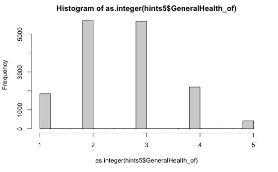

```r
hist(as.integer(hints5$GeneralHealth_of))
```

```r
hints5$GeneralHealth_i <- as.integer(hints5$GeneralHealth_of)
hints5$GeneralHealth_z <- zscore(hints5$GeneralHealth_i)
```

This is skewed, but not so skewed it hits my pre-registered criterion for transformation, so we will simply z-score it and proceed with that.

How about the other measures?

```r
for (dichot_var in c("MedConditions_Diabetes", "MedConditions_HighBP", "MedConditions_HeartCondition", "EverHadCancer")){
  print(dichot_var)
  print(table(hints5 %>% dplyr::select(dichot_var)))
  var_tally <- hints5 %>% dplyr::select(dichot_var) %>% .[[1]]
  print("proportion valid reaponses answering 'yes':")
  yes_tally = sum(var_tally=="Yes")
  no_tally = sum(var_tally=="No")
  print(yes_tally/(yes_tally+no_tally))
  #print(table(hints5 %>% select(dichot_var,"HINTSIsRural")))

}
```

```
[1] "MedConditions_Diabetes"

                  Missing data (Not Ascertained)                    Missing data (Filter Missing)    Question answered in error (Commission Error)             Inapplicable, coded 2 in UseInternet
                                             357                                                0                                                0                                                0
                                             Yes                                               No Missing data (Web partial - Question Never Seen)
                                            3368                                            12357                                               10
[1] "proportion valid reaponses answering 'yes':"
[1] 0.2141812
[1] "MedConditions_HighBP"

                  Missing data (Not Ascertained)                    Missing data (Filter Missing)    Question answered in error (Commission Error)             Inapplicable, coded 2 in UseInternet
                                             332                                                0                                                0                                                0
                                             Yes                                               No Missing data (Web partial - Question Never Seen)
                                            7133                                             8617                                               10
[1] "proportion valid reaponses answering 'yes':"
[1] 0.4528889
[1] "MedConditions_HeartCondition"

                  Missing data (Not Ascertained)                    Missing data (Filter Missing)    Question answered in error (Commission Error)             Inapplicable, coded 2 in UseInternet
                                             292                                                0                                                0                                                0
                                             Yes                                               No Missing data (Web partial - Question Never Seen)
                                            1606                                            14184                                               10
[1] "proportion valid reaponses answering 'yes':"
[1] 0.1017099
[1] "EverHadCancer"

                  Missing data (Not Ascertained)                                              Yes                                               No Missing data (Web partial - Question Never Seen)
                                             181                                             2579                                            13292                                               40
[1] "proportion valid reaponses answering 'yes':"
[1] 0.1624976
```

As per the pre-register, we will use the individual item MedConditions_HighBP, which has 45% of respondents answering yes, but rather than using MedConditions_Diabetes and MedConditions_HeartCondition, we will calculate an aggregate of all three measures and predict that aggregate.

```r
#dichotomize these variables so every value is either No, Yes, or NA.
MedConditions_vars <- c("MedConditions_Diabetes", "MedConditions_HighBP", "MedConditions_HeartCondition")
for (var_to_factorize in c(MedConditions_vars,"EverHadCancer")){
  hints5[[paste0(var_to_factorize,"_d")]]<-factor(hints5 %>% dplyr::select(var_to_factorize) %>% .[[1]],levels=c("No","Yes"))
  hints5[[paste0(var_to_factorize,"_i")]]<-as.integer(hints5[[paste0(var_to_factorize,"_d")]]=="Yes")
}
#take the count of the number of these three med conditions in an aggregate variable.
#note we're note including hte cancer diagnosis, which was pre-registered separately.
hints5$DiagnosesAggregate <- rowSums(hints5 %>% dplyr::select(sapply(MedConditions_vars,function(x){paste0(x,"_i")})))
```

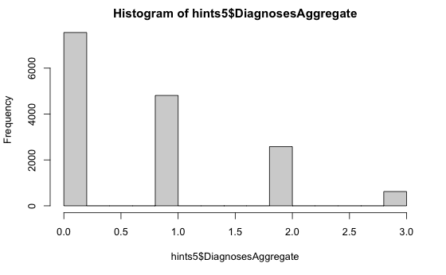

```r
hist(hints5$DiagnosesAggregate)
```

## Correlations between outcome variables and a few other important ones

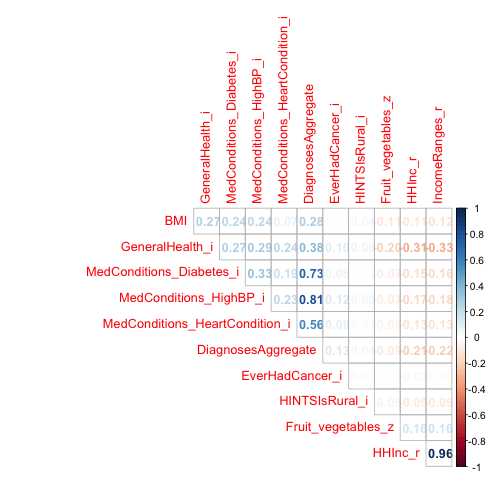

```r
data_to_correlate <- hints5[,c(
  "BMI","GeneralHealth_i","MedConditions_Diabetes_i","MedConditions_HighBP_i","MedConditions_HeartCondition_i","DiagnosesAggregate","EverHadCancer_i","HINTSIsRural_i","Fruit_vegetables_z",
  "HHInc_r","IncomeRanges_r"
  )]
cor_mat <- cor(data_to_correlate,use = "pairwise.complete.obs")
corrplot::corrplot(cor_mat,type="upper",diag=FALSE,method="number")
```

## H1. There are poorer health outcomes for rural areas compared to urban ones

To test this, we use regression.

So here, we’re testing general health for a start.

```r
#health_measures <- c("GeneralHealth", "MedConditions_Diabetes", "MedConditions_HighBP", "MedConditions_HeartCondition", EverHadCancer)
formula_rhs<-"~HINTSIsRural_i+Age_c+I(Age_c^2)+RacePP+Gender3C+filename"
formula_general <- paste0("GeneralHealth_i",formula_rhs)

print(formula_general)
```

```
[1] "GeneralHealth_i~HINTSIsRural_i+Age_c+I(Age_c^2)+RacePP+Gender3C+filename"
```

```r
rural_disparity <- lm(eval(formula_general),hints5)

summary(rural_disparity)
```

```
Call:
lm(formula = eval(formula_general), data = hints5)

Residuals:
     Min       1Q   Median       3Q      Max
-2.25401 -0.62631  0.03639  0.53843  2.88753

Coefficients:
                                                         Estimate Std. Error t value Pr(>|t|)
(Intercept)                                             2.340e+00  2.063e-02 113.442  < 2e-16 ***
HINTSIsRural_i                                          1.550e-01  2.203e-02   7.035 2.08e-12 ***
Age_c                                                   1.026e-02  9.098e-04  11.275  < 2e-16 ***
I(Age_c^2)                                             -2.359e-06  2.332e-05  -0.101   0.9194
RacePPBlack                                             3.038e-01  2.122e-02  14.316  < 2e-16 ***
RacePPMissing data (Not Ascertained)                    2.460e-01  3.397e-02   7.242 4.64e-13 ***
RacePPMultiple races selected                           2.875e-01  3.996e-02   7.193 6.61e-13 ***
RacePPChinese                                           9.563e-02  7.011e-02   1.364   0.1726
RacePPFilipino                                          1.780e-01  7.763e-02   2.293   0.0219 *
RacePPAsian Indian                                     -7.151e-02  8.088e-02  -0.884   0.3766
RacePPOther Asian                                       1.224e-01  8.278e-02   1.479   0.1393
RacePPAmerican Indian or Alaska Native                  4.156e-01  9.062e-02   4.586 4.56e-06 ***
RacePPPacific Islander                                  4.943e-01  1.036e-01   4.771 1.85e-06 ***
RacePPVietnamese                                        1.458e-01  1.203e-01   1.212   0.2253
RacePPMissing data (Web partial - Question Never Seen)  1.242e-02  1.654e-01   0.075   0.9401
RacePPKorean                                            1.402e-01  1.509e-01   0.929   0.3529
RacePPJapanese                                         -1.752e-01  1.757e-01  -0.997   0.3188
Gender3CMale                                           -3.624e-02  1.576e-02  -2.299   0.0215 *
Gender3CMissingOrMultiple                              -1.641e-03  3.282e-02  -0.050   0.9601
filenamehints5_cycle2_public.sav                       -4.781e-02  2.304e-02  -2.075   0.0380 *
filenamehints5_cycle3_public.sav                       -3.215e-02  2.107e-02  -1.526   0.1272
filenamehints5_cycle4_public.sav                       -1.969e-02  2.262e-02  -0.870   0.3841
---
Signif. codes:  0 ‘***’ 0.001 ‘**’ 0.01 ‘*’ 0.05 ‘.’ 0.1 ‘ ’ 1

Residual standard error: 0.9279 on 15403 degrees of freedom
  (667 observations deleted due to missingness)
Multiple R-squared:  0.05325,   Adjusted R-squared:  0.05195
F-statistic: 41.25 on 21 and 15403 DF,  p-value: < 2.2e-16
```

```r
formula_hbp <- paste0("MedConditions_HighBP_i",formula_rhs)
print(formula_hbp)
```

```
[1] "MedConditions_HighBP_i~HINTSIsRural_i+Age_c+I(Age_c^2)+RacePP+Gender3C+filename"
```

```r
rural_disparity <- glm(eval(formula_hbp),hints5, family = "binomial")

summary(rural_disparity)
```

```
Call:
glm(formula = eval(formula_hbp), family = "binomial", data = hints5)

Deviance Residuals:
    Min       1Q   Median       3Q      Max
-2.1875  -1.0074  -0.4139   1.0013   2.5801

Coefficients:
                                                         Estimate Std. Error z value Pr(>|z|)
(Intercept)                                            -1.693e+00  5.526e-02 -30.639  < 2e-16 ***
HINTSIsRural_i                                          2.008e-01  5.233e-02   3.838 0.000124 ***
Age_c                                                   7.818e-02  2.966e-03  26.358  < 2e-16 ***
I(Age_c^2)                                             -5.255e-04  6.761e-05  -7.772 7.70e-15 ***
RacePPBlack                                             8.849e-01  5.180e-02  17.082  < 2e-16 ***
RacePPMissing data (Not Ascertained)                    7.179e-02  8.269e-02   0.868 0.385280
RacePPMultiple races selected                           3.178e-01  9.775e-02   3.251 0.001149 **
RacePPChinese                                          -4.964e-01  1.886e-01  -2.632 0.008483 **
RacePPFilipino                                          5.987e-01  1.845e-01   3.245 0.001175 **
RacePPAsian Indian                                     -1.502e-01  2.151e-01  -0.698 0.485110
RacePPOther Asian                                      -1.752e-01  2.128e-01  -0.823 0.410302
RacePPAmerican Indian or Alaska Native                  4.895e-01  2.171e-01   2.255 0.024143 *
RacePPPacific Islander                                  2.684e-01  2.578e-01   1.041 0.297766
RacePPVietnamese                                       -1.365e-01  2.987e-01  -0.457 0.647566
RacePPMissing data (Web partial - Question Never Seen)  1.915e-01  4.600e-01   0.416 0.677112
RacePPKorean                                           -1.097e-01  3.604e-01  -0.304 0.760881
RacePPJapanese                                          4.482e-01  4.216e-01   1.063 0.287755
Gender3CMale                                            2.656e-01  3.797e-02   6.995 2.65e-12 ***
Gender3CMissingOrMultiple                               1.198e-02  7.821e-02   0.153 0.878216
filenamehints5_cycle2_public.sav                        1.793e-02  5.543e-02   0.324 0.746305
filenamehints5_cycle3_public.sav                       -2.863e-02  5.069e-02  -0.565 0.572178
filenamehints5_cycle4_public.sav                       -4.493e-02  5.451e-02  -0.824 0.409823
---
Signif. codes:  0 ‘***’ 0.001 ‘**’ 0.01 ‘*’ 0.05 ‘.’ 0.1 ‘ ’ 1

(Dispersion parameter for binomial family taken to be 1)

    Null deviance: 21102  on 15324  degrees of freedom
Residual deviance: 17938  on 15303  degrees of freedom
  (767 observations deleted due to missingness)
AIC: 17982

Number of Fisher Scoring iterations: 4
```

```r
print(exp(cbind(OR = coef(rural_disparity))))
```

```
                                                              OR
(Intercept)                                            0.1839664
HINTSIsRural_i                                         1.2224017
Age_c                                                  1.0813171
I(Age_c^2)                                             0.9994747
RacePPBlack                                            2.4228531
RacePPMissing data (Not Ascertained)                   1.0744277
RacePPMultiple races selected                          1.3740936
RacePPChinese                                          0.6087373
RacePPFilipino                                         1.8196952
RacePPAsian Indian                                     0.8605527
RacePPOther Asian                                      0.8393129
RacePPAmerican Indian or Alaska Native                 1.6314695
RacePPPacific Islander                                 1.3078510
RacePPVietnamese                                       0.8723728
RacePPMissing data (Web partial - Question Never Seen) 1.2111128
RacePPKorean                                           0.8961168
RacePPJapanese                                         1.5655173
Gender3CMale                                           1.3042144
Gender3CMissingOrMultiple                              1.0120566
filenamehints5_cycle2_public.sav                       1.0180934
filenamehints5_cycle3_public.sav                       0.9717720
filenamehints5_cycle4_public.sav                       0.9560691
```

Now we use the aggregate value.

```r
formula_hbp <- paste0("DiagnosesAggregate",formula_rhs)
print(formula_hbp)
```

```
[1] "DiagnosesAggregate~HINTSIsRural_i+Age_c+I(Age_c^2)+RacePP+Gender3C+filename"
```

```r
rural_disparity <- lm(formula_hbp,hints5)

summary(rural_disparity)
```

```
Call:
lm(formula = formula_hbp, data = hints5)

Residuals:
    Min      1Q  Median      3Q     Max
-1.8356 -0.5754 -0.1180  0.4431  3.0596

Coefficients:
                                                         Estimate Std. Error t value Pr(>|t|)
(Intercept)                                             2.272e-01  1.746e-02  13.012  < 2e-16 ***
HINTSIsRural_i                                          6.941e-02  1.873e-02   3.706 0.000212 ***
Age_c                                                   2.201e-02  7.692e-04  28.615  < 2e-16 ***
I(Age_c^2)                                             -1.571e-05  1.986e-05  -0.791 0.428881
RacePPBlack                                             3.211e-01  1.810e-02  17.739  < 2e-16 ***
RacePPMissing data (Not Ascertained)                    1.022e-01  2.901e-02   3.522 0.000430 ***
RacePPMultiple races selected                           1.146e-01  3.379e-02   3.391 0.000698 ***
RacePPChinese                                          -4.637e-02  5.907e-02  -0.785 0.432455
RacePPFilipino                                          2.495e-01  6.567e-02   3.799 0.000146 ***
RacePPAsian Indian                                      2.135e-02  6.847e-02   0.312 0.755205
RacePPOther Asian                                       7.478e-02  6.928e-02   1.079 0.280410
RacePPAmerican Indian or Alaska Native                  3.181e-01  7.650e-02   4.158 3.22e-05 ***
RacePPPacific Islander                                  2.438e-01  8.871e-02   2.748 0.006006 **
RacePPVietnamese                                        1.168e-01  1.010e-01   1.156 0.247587
RacePPMissing data (Web partial - Question Never Seen)  9.662e-02  1.411e-01   0.685 0.493464
RacePPKorean                                            2.658e-02  1.285e-01   0.207 0.836143
RacePPJapanese                                         -1.029e-01  1.503e-01  -0.685 0.493487
Gender3CMale                                            1.327e-01  1.335e-02   9.938  < 2e-16 ***
Gender3CMissingOrMultiple                               3.647e-02  2.796e-02   1.304 0.192238
filenamehints5_cycle2_public.sav                        3.538e-03  1.956e-02   0.181 0.856505
filenamehints5_cycle3_public.sav                        1.202e-03  1.787e-02   0.067 0.946342
filenamehints5_cycle4_public.sav                        7.060e-03  1.916e-02   0.369 0.712494
---
Signif. codes:  0 ‘***’ 0.001 ‘**’ 0.01 ‘*’ 0.05 ‘.’ 0.1 ‘ ’ 1

Residual standard error: 0.7796 on 15134 degrees of freedom
  (936 observations deleted due to missingness)
Multiple R-squared:  0.1952,    Adjusted R-squared:  0.194
F-statistic: 174.7 on 21 and 15134 DF,  p-value: < 2.2e-16
```

Finally, how do we do on the cancer score?

```r
table(hints5$EverHadCancer_i,hints5$HINTSIsRural)
```

```
    FALSE  TRUE
  0 11538  1754
  1  2186   393
```

```r
formula_cancer <- paste0("EverHadCancer_i",formula_rhs)
print(formula_cancer)
```

```
[1] "EverHadCancer_i~HINTSIsRural_i+Age_c+I(Age_c^2)+RacePP+Gender3C+filename"
```

```r
rural_disparity <- glm(eval(formula_cancer),hints5, family = "binomial")

summary(rural_disparity)
```

```
Call:
glm(formula = eval(formula_cancer), family = "binomial", data = hints5)

Deviance Residuals:
    Min       1Q   Median       3Q      Max
-1.1521  -0.6746  -0.4532  -0.2021   3.4186

Coefficients:
                                                         Estimate Std. Error z value Pr(>|z|)
(Intercept)                                            -3.104e+00  8.898e-02 -34.883  < 2e-16 ***
HINTSIsRural_i                                         -5.282e-02  6.443e-02  -0.820 0.412294
Age_c                                                   8.702e-02  5.218e-03  16.678  < 2e-16 ***
I(Age_c^2)                                             -6.399e-04  9.541e-05  -6.707 1.99e-11 ***
RacePPBlack                                            -5.026e-01  7.013e-02  -7.166 7.71e-13 ***
RacePPMissing data (Not Ascertained)                   -5.780e-01  1.168e-01  -4.948 7.49e-07 ***
RacePPMultiple races selected                          -2.036e-02  1.308e-01  -0.156 0.876263
RacePPChinese                                          -9.793e-01  3.095e-01  -3.165 0.001552 **
RacePPFilipino                                         -1.138e+00  3.355e-01  -3.391 0.000697 ***
RacePPAsian Indian                                     -9.892e-01  3.999e-01  -2.474 0.013371 *
RacePPOther Asian                                      -7.094e-01  3.440e-01  -2.062 0.039166 *
RacePPAmerican Indian or Alaska Native                 -6.158e-02  2.855e-01  -0.216 0.829244
RacePPPacific Islander                                 -1.011e+00  4.746e-01  -2.129 0.033248 *
RacePPVietnamese                                       -1.276e+00  6.047e-01  -2.109 0.034924 *
RacePPMissing data (Web partial - Question Never Seen) -9.008e+00  1.102e+02  -0.082 0.934849
RacePPKorean                                           -2.319e+00  1.022e+00  -2.270 0.023225 *
RacePPJapanese                                          1.323e-01  4.826e-01   0.274 0.784018
Gender3CMale                                           -4.502e-02  4.831e-02  -0.932 0.351406
Gender3CMissingOrMultiple                               1.214e-01  9.474e-02   1.281 0.200189
filenamehints5_cycle2_public.sav                        7.632e-02  7.082e-02   1.078 0.281156
filenamehints5_cycle3_public.sav                        1.579e-02  6.531e-02   0.242 0.808896
filenamehints5_cycle4_public.sav                        5.788e-02  6.976e-02   0.830 0.406740
---
Signif. codes:  0 ‘***’ 0.001 ‘**’ 0.01 ‘*’ 0.05 ‘.’ 0.1 ‘ ’ 1

(Dispersion parameter for binomial family taken to be 1)

    Null deviance: 13782  on 15520  degrees of freedom
Residual deviance: 12203  on 15499  degrees of freedom
  (571 observations deleted due to missingness)
AIC: 12247

Number of Fisher Scoring iterations: 10
```

- responded 0.16 points higher (poorer health) (b=0.16, p<0.001) on a 5-point scale for the question “In general, would you say your health is excellent, very good, good, fair, or poor?”
- In a logistic regression, were 22% more likely to have high blood pressure (OR=1.22, b=0.2, p<0.001)
- Scored 0.069 points higher on a 3-point scale tallying reports of high blood pressure, diabetes, or a heart condition
- no significantly different odds of having had cancer, although we only had 393 rural subjects with cancer, which makes for a small sample size.

Overall, that’s a strong result, and we can proceed to look at mediation factors.

## Rural health outcomes are mediated by fruit and vegetable consumption.

```r
library(mediation)
```

```r
run_HINTS_mediation <- function(outcome,mediator,is_logistic=FALSE){
  data_to_measure <- hints5[!is.na(hints5[[outcome]]),] %>% filter(Gender3C %in% c("Male","Female"))
  mb_formula <<-paste0(mediator,"~HINTSIsRural_i+Age_c+I(Age_c^2)+RacePP+Gender3C+filename")
  mb <<- lm(eval(mb_formula),data_to_measure)
  mc_formula<<- paste0(outcome, "~", mediator, "+HINTSIsRural_i+Age_c+I(Age_c^2)+RacePP+Gender3C+filename")
  #mc_direct <- paste0(outcome, "~HINTSIsRural_i+Age_c+I(Age_c^2)+RacePP+Gender3C+filename")
  ## these have to be global scope because they have to be accessed within the mediate function. d
  if(is_logistic){
    mc <<- glm(eval(mc_formula), data=data_to_measure,family="binomial")
    #m_direct <- glm(eval(mc_direct), data=data_to_measure,family="binomial")
  }else{
    mc <<- lm(eval(mc_formula), data=data_to_measure)
    #m_direct <- lm(eval(mc_direct), data=data_to_measure)
  }
  #print(mc_direct)
  #print(summary(m_direct))


  print(mb_formula)
  #print(summary(mb))
  print(mc_formula)

  mediation_model <- mediate(mb,mc,sims=boot_times, boot=TRUE,boot.ci.type = "bca",
                                  treat="HINTSIsRural_i",mediator=mediator)

  print(summary(mc))
  print(summary(mediation_model))
  return(mediation_model)

}
```

```r
library(mediation)
# GeneralHealth_i #linear
# MedConditions_HighBP_i #logistic
# DiagnosesAggregate #linear
# EverHadCancer_i #linear

set.seed(7042643)

mediation_result = run_HINTS_mediation("GeneralHealth_i", "Fruit_vegetables_z", is_logistic=FALSE)
```

```
[1] "Fruit_vegetables_z~HINTSIsRural_i+Age_c+I(Age_c^2)+RacePP+Gender3C+filename"
[1] "GeneralHealth_i~Fruit_vegetables_z+HINTSIsRural_i+Age_c+I(Age_c^2)+RacePP+Gender3C+filename"
```

```
Running nonparametric bootstrap
```

```
Call:
lm(formula = eval(mc_formula), data = data_to_measure)

Residuals:
    Min      1Q  Median      3Q     Max
-2.4221 -0.6193 -0.0218  0.5435  3.1579

Coefficients:
                                         Estimate Std. Error t value Pr(>|t|)
(Intercept)                             2.371e+00  2.845e-02  83.337  < 2e-16 ***
Fruit_vegetables_z                     -1.961e-01  1.149e-02 -17.065  < 2e-16 ***
HINTSIsRural_i                          1.333e-01  3.394e-02   3.927 8.70e-05 ***
Age_c                                   1.124e-02  1.402e-03   8.021 1.24e-15 ***
I(Age_c^2)                             -6.121e-05  3.707e-05  -1.651  0.09876 .
RacePPBlack                             3.012e-01  3.229e-02   9.328  < 2e-16 ***
RacePPMissing data (Not Ascertained)    3.065e-01  5.747e-02   5.333 9.97e-08 ***
RacePPMultiple races selected           3.403e-01  6.019e-02   5.654 1.64e-08 ***
RacePPChinese                           9.023e-02  1.047e-01   0.862  0.38883
RacePPFilipino                          3.716e-01  1.172e-01   3.170  0.00153 **
RacePPAsian Indian                     -1.479e-01  1.195e-01  -1.237  0.21604
RacePPOther Asian                       2.306e-01  1.503e-01   1.534  0.12520
RacePPAmerican Indian or Alaska Native  6.995e-01  1.566e-01   4.467 8.06e-06 ***
RacePPPacific Islander                  4.263e-01  1.695e-01   2.516  0.01191 *
RacePPVietnamese                        2.751e-02  1.639e-01   0.168  0.86669
RacePPKorean                            1.179e-01  1.823e-01   0.647  0.51787
RacePPJapanese                         -8.948e-02  2.038e-01  -0.439  0.66056
Gender3CMale                           -5.642e-02  2.311e-02  -2.441  0.01468 *
filenamehints5_cycle3_public.sav       -5.520e-02  2.568e-02  -2.149  0.03163 *
---
Signif. codes:  0 ‘***’ 0.001 ‘**’ 0.01 ‘*’ 0.05 ‘.’ 0.1 ‘ ’ 1

Residual standard error: 0.9087 on 6458 degrees of freedom
  (8124 observations deleted due to missingness)
Multiple R-squared:  0.09401,   Adjusted R-squared:  0.09148
F-statistic: 37.23 on 18 and 6458 DF,  p-value: < 2.2e-16


Causal Mediation Analysis

Nonparametric Bootstrap Confidence Intervals with the BCa Method

               Estimate 95% CI Lower 95% CI Upper p-value
ACME             0.0293       0.0182         0.04  <2e-16 ***
ADE              0.1333       0.1002         0.22  <2e-16 ***
Total Effect     0.1626       0.1177         0.24  <2e-16 ***
Prop. Mediated   0.1802       0.1132         0.23  <2e-16 ***
---
Signif. codes:  0 ‘***’ 0.001 ‘**’ 0.01 ‘*’ 0.05 ‘.’ 0.1 ‘ ’ 1

Sample Size Used: 6477


Simulations: 10
```

```r
# GeneralHealth_i #linear
# MedConditions_HighBP_i #logistic
# DiagnosesAggregate #linear
# EverHadCancer_i #linear

set.seed(7422649)

mediation_result = run_HINTS_mediation("MedConditions_HighBP_i", "Fruit_vegetables_z", is_logistic=TRUE)
```

```
[1] "Fruit_vegetables_z~HINTSIsRural_i+Age_c+I(Age_c^2)+RacePP+Gender3C+filename"
[1] "MedConditions_HighBP_i~Fruit_vegetables_z+HINTSIsRural_i+Age_c+I(Age_c^2)+RacePP+Gender3C+filename"
```

```
Running nonparametric bootstrap
```

```
Call:
glm(formula = eval(mc_formula), family = "binomial", data = data_to_measure)

Deviance Residuals:
    Min       1Q   Median       3Q      Max
-2.1148  -0.9847  -0.4179   0.9936   2.5924

Coefficients:
                                         Estimate Std. Error z value Pr(>|z|)
(Intercept)                            -1.7428653  0.0800297 -21.778  < 2e-16 ***
Fruit_vegetables_z                     -0.1237897  0.0286321  -4.323 1.54e-05 ***
HINTSIsRural_i                          0.1757977  0.0833983   2.108   0.0350 *
Age_c                                   0.0798186  0.0047184  16.916  < 2e-16 ***
I(Age_c^2)                             -0.0004899  0.0001109  -4.418 9.95e-06 ***
RacePPBlack                             0.8388156  0.0804162  10.431  < 2e-16 ***
RacePPMissing data (Not Ascertained)    0.0982961  0.1444747   0.680   0.4963
RacePPMultiple races selected           0.3806827  0.1519595   2.505   0.0122 *
RacePPChinese                          -0.3140701  0.2853211  -1.101   0.2710
RacePPFilipino                          0.6094791  0.2856230   2.134   0.0329 *
RacePPAsian Indian                      0.2615484  0.3151308   0.830   0.4066
RacePPOther Asian                       0.1460653  0.3910479   0.374   0.7088
RacePPAmerican Indian or Alaska Native  0.7386824  0.3886282   1.901   0.0573 .
RacePPPacific Islander                 -0.1068350  0.4429953  -0.241   0.8094
RacePPVietnamese                        0.1010739  0.4194302   0.241   0.8096
RacePPKorean                           -0.0346546  0.4480976  -0.077   0.9384
RacePPJapanese                          0.6761216  0.5163015   1.310   0.1903
Gender3CMale                            0.2665193  0.0572429   4.656 3.23e-06 ***
filenamehints5_cycle3_public.sav       -0.0610967  0.0636526  -0.960   0.3371
---
Signif. codes:  0 ‘***’ 0.001 ‘**’ 0.01 ‘*’ 0.05 ‘.’ 0.1 ‘ ’ 1

(Dispersion parameter for binomial family taken to be 1)

    Null deviance: 8834.8  on 6438  degrees of freedom
Residual deviance: 7429.6  on 6420  degrees of freedom
  (8066 observations deleted due to missingness)
AIC: 7467.6

Number of Fisher Scoring iterations: 4

```

[output cut: 8 more lines]

```
ADE (control)             0.03484      0.01105         0.07  <2e-16 ***
ADE (treated)             0.03485      0.01106         0.07  <2e-16 ***
Total Effect              0.03854      0.01411         0.07  <2e-16 ***
Prop. Mediated (control)  0.09566      0.07306         0.24  <2e-16 ***
Prop. Mediated (treated)  0.09599      0.07331         0.24  <2e-16 ***
ACME (average)            0.00369      0.00234         0.01  <2e-16 ***
ADE (average)             0.03485      0.01106         0.07  <2e-16 ***
Prop. Mediated (average)  0.09582      0.07319         0.24  <2e-16 ***
---
Signif. codes:  0 ‘***’ 0.001 ‘**’ 0.01 ‘*’ 0.05 ‘.’ 0.1 ‘ ’ 1

Sample Size Used: 6439


Simulations: 10
```

```r
# GeneralHealth_i #linear
# MedConditions_HighBP_i #logistic
# DiagnosesAggregate #linear
# EverHadCancer_i #linear



set.seed(4194457)
mediation_result = run_HINTS_mediation("DiagnosesAggregate", "Fruit_vegetables_z", is_logistic=FALSE)
```

```
[1] "Fruit_vegetables_z~HINTSIsRural_i+Age_c+I(Age_c^2)+RacePP+Gender3C+filename"
[1] "DiagnosesAggregate~Fruit_vegetables_z+HINTSIsRural_i+Age_c+I(Age_c^2)+RacePP+Gender3C+filename"
```

```
Running nonparametric bootstrap
```

```
Call:
lm(formula = eval(mc_formula), data = data_to_measure)

Residuals:
    Min      1Q  Median      3Q     Max
-1.6372 -0.5619 -0.1138  0.4152  3.1061

Coefficients:
                                         Estimate Std. Error t value Pr(>|t|)
(Intercept)                             2.182e-01  2.425e-02   8.997  < 2e-16 ***
Fruit_vegetables_z                     -5.313e-02  9.793e-03  -5.425  6.0e-08 ***
HINTSIsRural_i                          6.238e-02  2.910e-02   2.144  0.03209 *
Age_c                                   2.173e-02  1.194e-03  18.207  < 2e-16 ***
I(Age_c^2)                              5.152e-06  3.173e-05   0.162  0.87102
RacePPBlack                             3.188e-01  2.777e-02  11.479  < 2e-16 ***
RacePPMissing data (Not Ascertained)    1.220e-01  4.894e-02   2.493  0.01269 *
RacePPMultiple races selected           1.523e-01  5.128e-02   2.971  0.00298 **
RacePPChinese                          -2.839e-03  8.867e-02  -0.032  0.97446
RacePPFilipino                          2.749e-01  1.001e-01   2.748  0.00602 **
RacePPAsian Indian                      9.465e-02  1.012e-01   0.935  0.34966
RacePPOther Asian                       1.979e-01  1.256e-01   1.575  0.11532
RacePPAmerican Indian or Alaska Native  4.361e-01  1.326e-01   3.289  0.00101 **
RacePPPacific Islander                  3.849e-01  1.487e-01   2.589  0.00966 **
RacePPVietnamese                        1.098e-01  1.388e-01   0.791  0.42902
RacePPKorean                            1.328e-02  1.544e-01   0.086  0.93143
RacePPJapanese                         -3.320e-02  1.770e-01  -0.188  0.85118
Gender3CMale                            1.235e-01  1.972e-02   6.260  4.1e-10 ***
filenamehints5_cycle3_public.sav       -6.676e-03  2.193e-02  -0.304  0.76081
---
Signif. codes:  0 ‘***’ 0.001 ‘**’ 0.01 ‘*’ 0.05 ‘.’ 0.1 ‘ ’ 1

Residual standard error: 0.7694 on 6355 degrees of freedom
  (7972 observations deleted due to missingness)
Multiple R-squared:  0.2048,    Adjusted R-squared:  0.2025
F-statistic: 90.91 on 18 and 6355 DF,  p-value: < 2.2e-16


Causal Mediation Analysis

Nonparametric Bootstrap Confidence Intervals with the BCa Method

               Estimate 95% CI Lower 95% CI Upper p-value
ACME            0.00770      0.00634         0.01  <2e-16 ***
ADE             0.06238      0.02871         0.10  <2e-16 ***
Total Effect    0.07007      0.03549         0.11  <2e-16 ***
Prop. Mediated  0.10983      0.07602         0.22  <2e-16 ***
---
Signif. codes:  0 ‘***’ 0.001 ‘**’ 0.01 ‘*’ 0.05 ‘.’ 0.1 ‘ ’ 1

Sample Size Used: 6374


Simulations: 10
```

```r
# GeneralHealth_i #linear
# MedConditions_HighBP_i #logistic
# DiagnosesAggregate #linear
# EverHadCancer_i #linear



set.seed(9966743)
mediation_result = run_HINTS_mediation("EverHadCancer_i", "Fruit_vegetables_z", is_logistic=FALSE)
```

```
[1] "Fruit_vegetables_z~HINTSIsRural_i+Age_c+I(Age_c^2)+RacePP+Gender3C+filename"
[1] "EverHadCancer_i~Fruit_vegetables_z+HINTSIsRural_i+Age_c+I(Age_c^2)+RacePP+Gender3C+filename"
```

```
Running nonparametric bootstrap
```

```
Call:
lm(formula = eval(mc_formula), data = data_to_measure)

Residuals:
     Min       1Q   Median       3Q      Max
-0.54414 -0.20084 -0.10705 -0.01477  1.08909

Coefficients:
                                         Estimate Std. Error t value Pr(>|t|)
(Intercept)                             5.928e-02  1.081e-02   5.483 4.34e-08 ***
Fruit_vegetables_z                      4.717e-03  4.354e-03   1.083 0.278639
HINTSIsRural_i                         -1.839e-02  1.288e-02  -1.427 0.153538
Age_c                                   4.694e-03  5.328e-04   8.811  < 2e-16 ***
I(Age_c^2)                              4.722e-05  1.407e-05   3.355 0.000797 ***
RacePPBlack                            -7.054e-02  1.224e-02  -5.762 8.70e-09 ***
RacePPMissing data (Not Ascertained)   -7.132e-02  2.181e-02  -3.270 0.001080 **
RacePPMultiple races selected           2.977e-02  2.288e-02   1.301 0.193197
RacePPChinese                          -1.005e-01  3.988e-02  -2.521 0.011719 *
RacePPFilipino                         -6.054e-02  4.465e-02  -1.356 0.175138
RacePPAsian Indian                     -6.710e-02  4.514e-02  -1.486 0.137216
RacePPOther Asian                      -4.814e-02  5.651e-02  -0.852 0.394353
RacePPAmerican Indian or Alaska Native  7.514e-02  5.798e-02   1.296 0.195038
RacePPPacific Islander                 -4.310e-02  6.455e-02  -0.668 0.504317
RacePPVietnamese                       -4.026e-02  6.243e-02  -0.645 0.519048
RacePPKorean                           -1.263e-01  6.944e-02  -1.819 0.068916 .
RacePPJapanese                          3.557e-02  7.761e-02   0.458 0.646784
Gender3CMale                            5.897e-03  8.771e-03   0.672 0.501409
filenamehints5_cycle3_public.sav       -2.107e-03  9.758e-03  -0.216 0.829088
---
Signif. codes:  0 ‘***’ 0.001 ‘**’ 0.01 ‘*’ 0.05 ‘.’ 0.1 ‘ ’ 1

Residual standard error: 0.3461 on 6510 degrees of freedom
  (8129 observations deleted due to missingness)
Multiple R-squared:  0.0923,    Adjusted R-squared:  0.08979
F-statistic: 36.77 on 18 and 6510 DF,  p-value: < 2.2e-16


Causal Mediation Analysis

Nonparametric Bootstrap Confidence Intervals with the BCa Method

               Estimate 95% CI Lower 95% CI Upper p-value
ACME           -0.00069     -0.00201         0.00     0.4
ADE            -0.01839     -0.04065         0.00     0.2
Total Effect   -0.01908     -0.04142         0.00  <2e-16 ***
Prop. Mediated  0.03616      0.02807         3.24     0.4
---
Signif. codes:  0 ‘***’ 0.001 ‘**’ 0.01 ‘*’ 0.05 ‘.’ 0.1 ‘ ’ 1

Sample Size Used: 6529


Simulations: 10
```

## Rural health outcomes are mediated by income.

```r
#hist(hints5$HHInc_r)
library(mediation)
# GeneralHealth_i #linear
# MedConditions_HighBP_i #logistic
# DiagnosesAggregate #linear
# EverHadCancer_i #linear

set.seed(06803234)

mediation_result = run_HINTS_mediation("GeneralHealth_i", "IncomeRanges_r", is_logistic=FALSE)
```

```
[1] "IncomeRanges_r~HINTSIsRural_i+Age_c+I(Age_c^2)+RacePP+Gender3C+filename"
[1] "GeneralHealth_i~IncomeRanges_r+HINTSIsRural_i+Age_c+I(Age_c^2)+RacePP+Gender3C+filename"
```

```
Running nonparametric bootstrap
```

```
Call:
lm(formula = eval(mc_formula), data = data_to_measure)

Residuals:
     Min       1Q   Median       3Q      Max
-2.45043 -0.58512 -0.05891  0.62006  3.10966

Coefficients:
                                         Estimate Std. Error t value Pr(>|t|)
(Intercept)                             2.343e+00  2.083e-02 112.489  < 2e-16 ***
IncomeRanges_r                         -1.269e-01  3.671e-03 -34.566  < 2e-16 ***
HINTSIsRural_i                          7.264e-02  2.283e-02   3.182 0.001468 **
Age_c                                   1.135e-02  9.243e-04  12.282  < 2e-16 ***
I(Age_c^2)                             -1.265e-04  2.474e-05  -5.111 3.24e-07 ***
RacePPBlack                             1.166e-01  2.237e-02   5.210 1.92e-07 ***
RacePPMissing data (Not Ascertained)    1.552e-01  4.065e-02   3.817 0.000135 ***
RacePPMultiple races selected           2.017e-01  4.017e-02   5.020 5.25e-07 ***
RacePPChinese                           5.308e-02  7.065e-02   0.751 0.452436
RacePPFilipino                          2.154e-01  7.583e-02   2.841 0.004505 **
RacePPAsian Indian                     -1.645e-02  8.102e-02  -0.203 0.839058
RacePPOther Asian                       1.016e-01  8.143e-02   1.247 0.212345
RacePPAmerican Indian or Alaska Native  2.438e-01  8.983e-02   2.714 0.006663 **
RacePPPacific Islander                  2.075e-01  1.068e-01   1.943 0.052027 .
RacePPVietnamese                        6.637e-02  1.212e-01   0.548 0.583870
RacePPKorean                            1.920e-01  1.503e-01   1.277 0.201523
RacePPJapanese                         -7.345e-02  1.778e-01  -0.413 0.679487
Gender3CMale                            2.497e-02  1.568e-02   1.592 0.111311
filenamehints5_cycle2_public.sav       -2.405e-02  2.354e-02  -1.021 0.307083
filenamehints5_cycle3_public.sav       -2.624e-03  2.147e-02  -0.122 0.902720
filenamehints5_cycle4_public.sav        1.772e-02  2.305e-02   0.769 0.442097
---
Signif. codes:  0 ‘***’ 0.001 ‘**’ 0.01 ‘*’ 0.05 ‘.’ 0.1 ‘ ’ 1

Residual standard error: 0.8869 on 13409 degrees of freedom
  (1171 observations deleted due to missingness)
Multiple R-squared:  0.1293,    Adjusted R-squared:  0.128
F-statistic: 99.56 on 20 and 13409 DF,  p-value: < 2.2e-16


Causal Mediation Analysis

Nonparametric Bootstrap Confidence Intervals with the BCa Method

               Estimate 95% CI Lower 95% CI Upper p-value
ACME             0.0829       0.0764         0.09  <2e-16 ***
ADE              0.0726       0.0373         0.10  <2e-16 ***
Total Effect     0.1556       0.1248         0.19  <2e-16 ***
Prop. Mediated   0.5330       0.4604         0.70  <2e-16 ***
---
Signif. codes:  0 ‘***’ 0.001 ‘**’ 0.01 ‘*’ 0.05 ‘.’ 0.1 ‘ ’ 1

Sample Size Used: 13430


Simulations: 10
```

```r
# GeneralHealth_i #linear
# MedConditions_HighBP_i #logistic
# DiagnosesAggregate #linear
# EverHadCancer_i #linear

set.seed(96079559)

mediation_result = run_HINTS_mediation("MedConditions_HighBP_i", "IncomeRanges_r", is_logistic=TRUE)
```

```
[1] "IncomeRanges_r~HINTSIsRural_i+Age_c+I(Age_c^2)+RacePP+Gender3C+filename"
[1] "MedConditions_HighBP_i~IncomeRanges_r+HINTSIsRural_i+Age_c+I(Age_c^2)+RacePP+Gender3C+filename"
```

```
Running nonparametric bootstrap
```

```
Call:
glm(formula = eval(mc_formula), family = "binomial", data = data_to_measure)

Deviance Residuals:
    Min       1Q   Median       3Q      Max
-2.2055  -0.9738  -0.4216   0.9830   2.6089

Coefficients:
                                         Estimate Std. Error z value Pr(>|z|)
(Intercept)                            -1.654e+00  5.828e-02 -28.378  < 2e-16 ***
IncomeRanges_r                         -1.091e-01  9.297e-03 -11.737  < 2e-16 ***
HINTSIsRural_i                          1.313e-01  5.714e-02   2.299  0.02153 *
Age_c                                   7.931e-02  3.130e-03  25.340  < 2e-16 ***
I(Age_c^2)                             -6.258e-04  7.418e-05  -8.436  < 2e-16 ***
RacePPBlack                             7.531e-01  5.710e-02  13.188  < 2e-16 ***
RacePPMissing data (Not Ascertained)   -1.956e-01  1.070e-01  -1.827  0.06763 .
RacePPMultiple races selected           2.286e-01  1.041e-01   2.196  0.02813 *
RacePPChinese                          -5.186e-01  2.012e-01  -2.578  0.00993 **
RacePPFilipino                          7.151e-01  1.895e-01   3.774  0.00016 ***
RacePPAsian Indian                     -7.615e-02  2.224e-01  -0.342  0.73202
RacePPOther Asian                      -2.276e-01  2.201e-01  -1.034  0.30106
RacePPAmerican Indian or Alaska Native  2.740e-01  2.261e-01   1.211  0.22571
RacePPPacific Islander                 -5.753e-02  2.805e-01  -0.205  0.83750
RacePPVietnamese                       -9.909e-02  3.170e-01  -0.313  0.75462
RacePPKorean                            3.769e-02  3.770e-01   0.100  0.92035
RacePPJapanese                          6.514e-01  4.557e-01   1.429  0.15292
Gender3CMale                            3.289e-01  3.990e-02   8.241  < 2e-16 ***
filenamehints5_cycle2_public.sav       -1.702e-02  5.976e-02  -0.285  0.77584
filenamehints5_cycle3_public.sav       -4.732e-02  5.450e-02  -0.868  0.38532
filenamehints5_cycle4_public.sav       -5.764e-02  5.864e-02  -0.983  0.32564
---
Signif. codes:  0 ‘***’ 0.001 ‘**’ 0.01 ‘*’ 0.05 ‘.’ 0.1 ‘ ’ 1

(Dispersion parameter for binomial family taken to be 1)

    Null deviance: 18343  on 13352  degrees of freedom
Residual deviance: 15395  on 13332  degrees of freedom
  (1152 observations deleted due to missingness)
AIC: 15437

```

[output cut: 10 more lines]

```
ADE (control)             0.02603      0.00888         0.05  <2e-16 ***
ADE (treated)             0.02606      0.00890         0.05  <2e-16 ***
Total Effect              0.04022      0.02288         0.06  <2e-16 ***
Prop. Mediated (control)  0.35196      0.25773         0.65  <2e-16 ***
Prop. Mediated (treated)  0.35276      0.25809         0.65  <2e-16 ***
ACME (average)            0.01417      0.01299         0.02  <2e-16 ***
ADE (average)             0.02605      0.00889         0.05  <2e-16 ***
Prop. Mediated (average)  0.35236      0.25791         0.65  <2e-16 ***
---
Signif. codes:  0 ‘***’ 0.001 ‘**’ 0.01 ‘*’ 0.05 ‘.’ 0.1 ‘ ’ 1

Sample Size Used: 13353


Simulations: 10
```

```r
# GeneralHealth_i #linear
# MedConditions_HighBP_i #logistic
# DiagnosesAggregate #linear
# EverHadCancer_i #linear



set.seed(30738241)
mediation_result = run_HINTS_mediation("DiagnosesAggregate", "IncomeRanges_r", is_logistic=FALSE)
```

```
[1] "IncomeRanges_r~HINTSIsRural_i+Age_c+I(Age_c^2)+RacePP+Gender3C+filename"
[1] "DiagnosesAggregate~IncomeRanges_r+HINTSIsRural_i+Age_c+I(Age_c^2)+RacePP+Gender3C+filename"
```

```
Running nonparametric bootstrap
```

```
Call:
lm(formula = eval(mc_formula), data = data_to_measure)

Residuals:
    Min      1Q  Median      3Q     Max
-1.8693 -0.5479 -0.1178  0.4488  2.8844

Coefficients:
                                         Estimate Std. Error t value Pr(>|t|)
(Intercept)                             2.391e-01  1.812e-02  13.194  < 2e-16 ***
IncomeRanges_r                         -5.538e-02  3.200e-03 -17.305  < 2e-16 ***
HINTSIsRural_i                          2.582e-02  1.992e-02   1.296  0.19484
Age_c                                   2.255e-02  8.037e-04  28.054  < 2e-16 ***
I(Age_c^2)                             -6.382e-05  2.168e-05  -2.944  0.00324 **
RacePPBlack                             2.410e-01  1.958e-02  12.310  < 2e-16 ***
RacePPMissing data (Not Ascertained)    2.593e-02  3.560e-02   0.728  0.46642
RacePPMultiple races selected           8.898e-02  3.492e-02   2.548  0.01085 *
RacePPChinese                          -5.686e-02  6.125e-02  -0.928  0.35327
RacePPFilipino                          2.923e-01  6.576e-02   4.445 8.85e-06 ***
RacePPAsian Indian                      4.274e-02  7.030e-02   0.608  0.54320
RacePPOther Asian                       4.845e-02  7.009e-02   0.691  0.48941
RacePPAmerican Indian or Alaska Native  2.327e-01  7.802e-02   2.982  0.00286 **
RacePPPacific Islander                  1.673e-01  9.432e-02   1.774  0.07612 .
RacePPVietnamese                        1.518e-01  1.047e-01   1.450  0.14712
RacePPKorean                            3.021e-02  1.318e-01   0.229  0.81867
RacePPJapanese                         -2.599e-02  1.568e-01  -0.166  0.86832
Gender3CMale                            1.611e-01  1.365e-02  11.803  < 2e-16 ***
filenamehints5_cycle2_public.sav       -5.177e-04  2.053e-02  -0.025  0.97988
filenamehints5_cycle3_public.sav        2.720e-04  1.871e-02   0.015  0.98840
filenamehints5_cycle4_public.sav        1.422e-02  2.007e-02   0.709  0.47855
---
Signif. codes:  0 ‘***’ 0.001 ‘**’ 0.01 ‘*’ 0.05 ‘.’ 0.1 ‘ ’ 1

Residual standard error: 0.7664 on 13200 degrees of freedom
  (1125 observations deleted due to missingness)
Multiple R-squared:  0.2165,    Adjusted R-squared:  0.2153
F-statistic: 182.3 on 20 and 13200 DF,  p-value: < 2.2e-16


Causal Mediation Analysis

Nonparametric Bootstrap Confidence Intervals with the BCa Method

               Estimate 95% CI Lower 95% CI Upper p-value
ACME            0.03605      0.03101         0.04  <2e-16 ***
ADE             0.02582     -0.00949         0.05     0.4
Total Effect    0.06187      0.02675         0.09  <2e-16 ***
Prop. Mediated  0.58266      0.45505         1.38  <2e-16 ***
---
Signif. codes:  0 ‘***’ 0.001 ‘**’ 0.01 ‘*’ 0.05 ‘.’ 0.1 ‘ ’ 1

Sample Size Used: 13221


Simulations: 10
```

```r
# GeneralHealth_i #linear
# MedConditions_HighBP_i #logistic
# DiagnosesAggregate #linear
# EverHadCancer_i #linear



set.seed(76567222)
mediation_result = run_HINTS_mediation("EverHadCancer_i", "IncomeRanges_r", is_logistic=FALSE)
```

```
[1] "IncomeRanges_r~HINTSIsRural_i+Age_c+I(Age_c^2)+RacePP+Gender3C+filename"
[1] "EverHadCancer_i~IncomeRanges_r+HINTSIsRural_i+Age_c+I(Age_c^2)+RacePP+Gender3C+filename"
```

```
Running nonparametric bootstrap
```

```
Call:
lm(formula = eval(mc_formula), data = data_to_measure)

Residuals:
     Min       1Q   Median       3Q      Max
-0.56431 -0.19851 -0.10583 -0.01969  1.07200

Coefficients:
                                         Estimate Std. Error t value Pr(>|t|)
(Intercept)                             6.433e-02  8.112e-03   7.931 2.35e-15 ***
IncomeRanges_r                          2.429e-03  1.428e-03   1.701 0.088920 .
HINTSIsRural_i                         -7.911e-03  8.882e-03  -0.891 0.373136
Age_c                                   4.258e-03  3.603e-04  11.819  < 2e-16 ***
I(Age_c^2)                              6.021e-05  9.630e-06   6.253 4.15e-10 ***
RacePPBlack                            -5.651e-02  8.707e-03  -6.490 8.89e-11 ***
RacePPMissing data (Not Ascertained)   -6.927e-02  1.581e-02  -4.381 1.19e-05 ***
RacePPMultiple races selected          -1.952e-04  1.564e-02  -0.012 0.990044
RacePPChinese                          -8.800e-02  2.750e-02  -3.200 0.001380 **
RacePPFilipino                         -1.117e-01  2.950e-02  -3.787 0.000153 ***
RacePPAsian Indian                     -8.155e-02  3.151e-02  -2.588 0.009652 **
RacePPOther Asian                      -6.051e-02  3.154e-02  -1.919 0.055053 .
RacePPAmerican Indian or Alaska Native -1.310e-02  3.490e-02  -0.375 0.707433
RacePPPacific Islander                 -8.829e-02  4.170e-02  -2.117 0.034255 *
RacePPVietnamese                       -8.737e-02  4.732e-02  -1.847 0.064839 .
RacePPKorean                           -1.682e-01  5.870e-02  -2.866 0.004159 **
RacePPJapanese                         -1.199e-03  6.942e-02  -0.017 0.986217
Gender3CMale                           -7.844e-03  6.102e-03  -1.285 0.198652
filenamehints5_cycle2_public.sav        6.119e-03  9.166e-03   0.668 0.504394
filenamehints5_cycle3_public.sav       -1.474e-03  8.353e-03  -0.177 0.859898
filenamehints5_cycle4_public.sav        2.381e-03  8.980e-03   0.265 0.790925
---
Signif. codes:  0 ‘***’ 0.001 ‘**’ 0.01 ‘*’ 0.05 ‘.’ 0.1 ‘ ’ 1

Residual standard error: 0.3463 on 13508 degrees of freedom
  (1129 observations deleted due to missingness)
Multiple R-squared:  0.09096,   Adjusted R-squared:  0.08961
F-statistic: 67.58 on 20 and 13508 DF,  p-value: < 2.2e-16


Causal Mediation Analysis

Nonparametric Bootstrap Confidence Intervals with the BCa Method

               Estimate 95% CI Lower 95% CI Upper p-value
ACME           -0.00160     -0.00226         0.00  <2e-16 ***
ADE            -0.00791     -0.01727         0.01     0.4
Total Effect   -0.00951     -0.01867         0.01     0.4
Prop. Mediated  0.16814     -0.51923         0.36     0.4
---
Signif. codes:  0 ‘***’ 0.001 ‘**’ 0.01 ‘*’ 0.05 ‘.’ 0.1 ‘ ’ 1

Sample Size Used: 13529


Simulations: 10
```